# Principios y Prácticas de SEM y MLM (5ed)

Tema 2.1 Análisis Factorial Exploratorio (EFA)

Author

Affiliation

Efraín García Sánchez

CIMCYC — Universidad de Granada

Published

May 15, 2026

# Práctica

## Instalar nuevos paquetes

Este bloque muestra cómo instalar los paquetes necesarios.

```r
install.packages("psychTools")
```

## Cargar los paquetes

Este bloque carga los paquetes necesarios para la práctica.

```r
library(tidyverse)        # manipulación y visualización de datos
library(easystats)        # Paquetes para análisis estadísticos
library(sjPlot)           # para visualización de resultados, tables y figuras
library(sjmisc)           # funciones para manipulación de datos
library(psych)            # para análisis psicométricos
library(psychTools)       # para extensiones del paquete psych
```

## Importar los datos: con etiquetas (para conservar los labels)

Este bloque importa la base de datos que se usará en la práctica.

```r
data_labels <- haven::read_sav(
  here::here("data",
  "northampton_student_health_data_package",
  "northampton_student_health_labelled.sav"))

glimpse(data_labels)
```

```
Rows: 590
Columns: 61
$ id                             <dbl> 1, 2, 3, 4, 5, 6, 7, 8, 9, 10, 11, 12, …
$ age_group                      <dbl+lbl> 1, 1, 1, 1, 1, 1, 2, 4, 1, 1, 1, 1,…
$ gender                         <dbl+lbl> 2, 1, 1, 1, 1, 2, 1, 1, 2, 2, 2, 2,…
$ sexual_orientation             <dbl+lbl> 1, 2, 1, 3, 1, 1, 1, 1, 1, 1, 1, 1,…
$ ethnicity                      <dbl+lbl> 1, 1, 1, 2, 1, 3, 1, 1, 1, 3, 1, 1,…
$ study_mode                     <dbl+lbl> 1, 1, 1, 1, 1, 1, 1, 2, 1, 1, 1, 1,…
$ study_level                    <dbl+lbl> 3, 3, 3, 3, 2, 6, 4, 3, 1, 2, 1, 1,…
$ living_situation               <dbl+lbl> 1, 2, 1, 3, 2, 4, 3, 3, 1, 2, 4, 1,…
$ phys_health                    <dbl+lbl> 3, 4, 4, 3, 4, 5, 5, 1, 4, 4, 4, 5,…
$ ment_health                    <dbl+lbl> 4, 3, 2, 4, 3, 3, 2, 1, 4, 4, 3, 5,…
$ social_connect                 <dbl+lbl> 4, 3, 1, 1, 2, 3, 2, 4, 4, 3, 3, 3,…
$ sitting_weekday_hours          <dbl> 8, 5, 7, 9, NA, 5, 11, 13, 6, 5, 12, 6,…
$ sleep_quality                  <dbl> 8, 7, 4, 7, 2, 5, 3, 8, 7, 2, 9, 7, 3, …
```

[output cut: 48 more lines]

## Importar los datos: solo numéricos (recomendado para evitar conflictos con paquetes)

Este bloque importa la base de datos que se usará en la práctica.

```r
data <- readr::read_csv(
  here::here("data",
  "northampton_student_health_data_package",
  "northampton_student_health_numeric.csv"))

glimpse(data)
```

```
Rows: 590
Columns: 61
$ id                             <dbl> 1, 2, 3, 4, 5, 6, 7, 8, 9, 10, 11, 12, …
$ age_group                      <dbl> 1, 1, 1, 1, 1, 1, 2, 4, 1, 1, 1, 1, 1, …
$ gender                         <dbl> 2, 1, 1, 1, 1, 2, 1, 1, 2, 2, 2, 2, 2, …
$ sexual_orientation             <dbl> 1, 2, 1, 3, 1, 1, 1, 1, 1, 1, 1, 1, 1, …
$ ethnicity                      <dbl> 1, 1, 1, 2, 1, 3, 1, 1, 1, 3, 1, 1, 1, …
$ study_mode                     <dbl> 1, 1, 1, 1, 1, 1, 1, 2, 1, 1, 1, 1, 1, …
$ study_level                    <dbl> 3, 3, 3, 3, 2, 6, 4, 3, 1, 2, 1, 1, 1, …
$ living_situation               <dbl> 1, 2, 1, 3, 2, 4, 3, 3, 1, 2, 4, 1, 1, …
$ phys_health                    <dbl> 3, 4, 4, 3, 4, 5, 5, 1, 4, 4, 4, 5, 5, …
$ ment_health                    <dbl> 4, 3, 2, 4, 3, 3, 2, 1, 4, 4, 3, 5, 3, …
$ social_connect                 <dbl> 4, 3, 1, 1, 2, 3, 2, 4, 4, 3, 3, 3, 2, …
$ sitting_weekday_hours          <dbl> 8, 5, 7, 9, NA, 5, 11, 13, 6, 5, 12, 6,…
$ sleep_quality                  <dbl> 8, 7, 4, 7, 2, 5, 3, 8, 7, 2, 9, 7, 3, …
```

[output cut: 48 more lines]

## Seleccionar un subconjunto de datos para el EFA

Este bloque prepara o verifica las variables seleccionadas para el análisis.

```r
data_prepare <- data |>
  dplyr::select(starts_with("food_prepare_")) # selecciona todas las variables que empiezan con "food_prepare_"

# revisamos los nombre
names(data_prepare)
```

```
[1] "food_prepare_self"             "food_prepare_parent_caregiver"
[3] "food_prepare_partner"          "food_prepare_friends"
[5] "food_prepare_housemates"       "food_prepare_other_family"
[7] "food_prepare_other"            "food_prepare_none"
```

## Revisamos los datos que vamos a incluir: análisis descriptivos

Este bloque obtiene descriptivos para revisar las variables seleccionadas.

```r
psych::describe(data_prepare)
```

|  | vars | n | mean | sd | median | trimmed | mad | min | max | range | skew | kurtosis | se |
| --- | --- | --- | --- | --- | --- | --- | --- | --- | --- | --- | --- | --- | --- |
| food_prepare_self | 1 | 590 | 0.886440678 | 0.31754450 | 1 | 0.98305085 | 0 | 0 | 1 | 1 | -2.429806 | 3.910592 | 0.013073100 |
| food_prepare_parent_caregiver | 2 | 590 | 0.108474576 | 0.31124272 | 0 | 0.01059322 | 0 | 0 | 1 | 1 | 2.511621 | 4.315561 | 0.012813660 |
| food_prepare_partner | 3 | 590 | 0.137288136 | 0.34444330 | 0 | 0.04661017 | 0 | 0 | 1 | 1 | 2.102506 | 2.424651 | 0.014180506 |
| food_prepare_friends | 4 | 590 | 0.022033898 | 0.14691831 | 0 | 0.00000000 | 0 | 0 | 1 | 1 | 6.495528 | 40.260128 | 0.006048531 |
| food_prepare_housemates | 5 | 590 | 0.027118644 | 0.16256696 | 0 | 0.00000000 | 0 | 0 | 1 | 1 | 5.807821 | 31.784660 | 0.006692776 |
| food_prepare_other_family | 6 | 590 | 0.035593220 | 0.18543091 | 0 | 0.00000000 | 0 | 0 | 1 | 1 | 5.000457 | 23.043636 | 0.007634070 |
| food_prepare_other | 7 | 590 | 0.037288136 | 0.18962773 | 0 | 0.00000000 | 0 | 0 | 1 | 1 | 4.871941 | 21.772725 | 0.007806850 |
| food_prepare_none | 8 | 590 | 0.001694915 | 0.04116935 | 0 | 0.00000000 | 0 | 0 | 1 | 1 | 24.166547 | 583.010161 | 0.001694915 |

Este bloque prepara o verifica las variables seleccionadas para el análisis.

```r
data_prepare <- data_prepare |>
  select(-food_prepare_none) # para eliminar una variable - o !

# revisamos
names(data_prepare)
```

```
[1] "food_prepare_self"             "food_prepare_parent_caregiver"
[3] "food_prepare_partner"          "food_prepare_friends"
[5] "food_prepare_housemates"       "food_prepare_other_family"
[7] "food_prepare_other"
```

## Revisamos los datos que vamos a incluir: revisamos items invertidos

Este bloque invierte el ítem para alinear su dirección con el constructo.

```r
data_prepare <- data_prepare |>
  datawizard::reverse(select = "food_prepare_self",
                      range = c(0,1))
```

## Revisamos los datos que vamos a incluir: ver distribuciones

Este bloque visualiza la distribución de las respuestas por ítem.

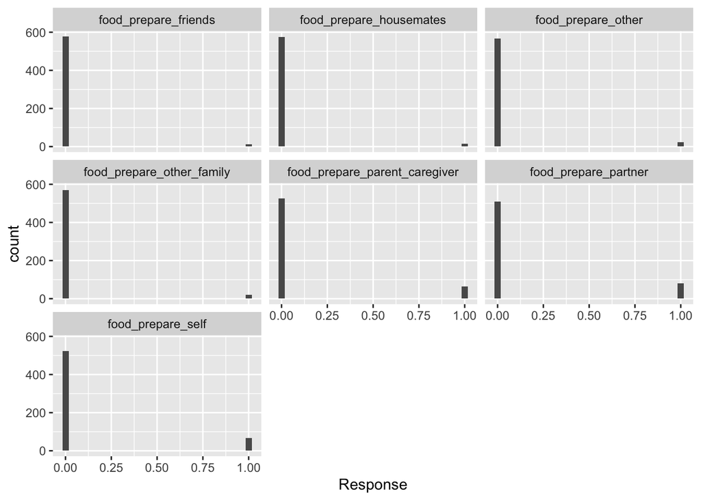

```r
data_prepare |>
  tidyr::pivot_longer(
    cols = 1:7,
    names_to = "Item",
    values_to = "Response"
  ) |>
  ggplot2::ggplot(mapping = aes(Response)) +
  geom_histogram() +
  facet_wrap(~ Item)
```

## ¿Los datos son apropiados para un EFA? Inspección manual

Este bloque calcula las correlaciones entre las variables seleccionadas.

```r
data_cor <- data_prepare |>
  correlation::correlation(method = "tetrachoric") # porque usamos variables dicotómicas; dejar en blanco si se usa Pearson
```

[output not shown]

Este bloque muestra la matriz de correlaciones en un formato más legible.

```r
data_cor |>
  correlation::display()
```

Correlation Matrix (tetrachoric-method)

| Parameter1 | Parameter2 | rho | 95% CI | t(588) | p |
| --- | --- | --- | --- | --- | --- |
| food_prepare_self | food_prepare_parent_caregiver | 0.65 | (0.60, 0.70) | 20.89 | < .001*** |
| food_prepare_self | food_prepare_partner | 0.50 | (0.43, 0.56) | 13.87 | < .001*** |
| food_prepare_self | food_prepare_friends | -0.09 | (-0.17, -8.73e-03) | -2.18 | 0.180 |
| food_prepare_self | food_prepare_housemates | 0.03 | (-0.06, 0.11) | 0.61 | > .999 |
| food_prepare_self | food_prepare_other_family | 0.53 | (0.47, 0.58) | 15.00 | < .001*** |
| food_prepare_self | food_prepare_other | 0.55 | (0.50, 0.61) | 16.16 | < .001*** |
| food_prepare_parent_caregiver | food_prepare_partner | -0.03 | (-0.11, 0.05) | -0.81 | > .999 |
| food_prepare_parent_caregiver | food_prepare_friends | -0.08 | (-0.16, 2.13e-03) | -1.91 | 0.282 |
| food_prepare_parent_caregiver | food_prepare_housemates | -0.13 | (-0.20, -0.04) | -3.06 | 0.021* |
| food_prepare_parent_caregiver | food_prepare_other_family | -0.31 | (-0.38, -0.23) | -7.81 | < .001*** |
| food_prepare_parent_caregiver | food_prepare_other | -0.32 | (-0.39, -0.24) | -8.06 | < .001*** |
| food_prepare_partner | food_prepare_friends | -0.27 | (-0.34, -0.19) | -6.74 | < .001*** |
| food_prepare_partner | food_prepare_housemates | -0.31 | (-0.38, -0.23) | -7.80 | < .001*** |
| food_prepare_partner | food_prepare_other_family | -0.24 | (-0.32, -0.16) | -6.04 | < .001*** |
| food_prepare_partner | food_prepare_other | -0.25 | (-0.33, -0.17) | -6.32 | < .001*** |
| food_prepare_friends | food_prepare_housemates | 0.54 | (0.48, 0.60) | 15.65 | < .001*** |
| food_prepare_friends | food_prepare_other_family | 3.43e-03 | (-0.08, 0.08) | 0.08 | > .999 |
| food_prepare_friends | food_prepare_other | -5.28e-03 | (-0.09, 0.08) | -0.13 | > .999 |
| food_prepare_housemates | food_prepare_other_family | 0.12 | (0.04, 0.20) | 2.97 | 0.025* |
| food_prepare_housemates | food_prepare_other | 0.11 | (0.03, 0.19) | 2.72 | 0.047* |
| food_prepare_other_family | food_prepare_other | 1.00 | (1.00, 1.00) | 582.45 | < .001*** |

p-value adjustment method: Holm (1979) Observations: 590

Este bloque resume y visualiza el patrón de correlaciones.

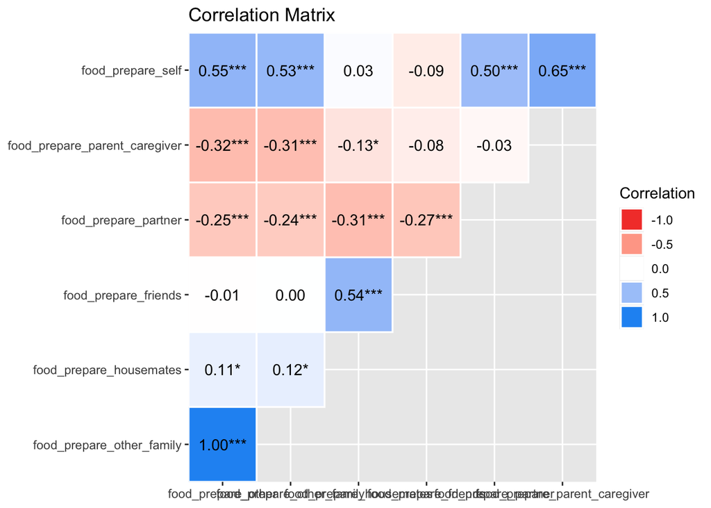

```r
data_cor |>
  summary() |>
  plot()
```

Este bloque prepara o verifica las variables seleccionadas para el análisis.

```r
data_prepare <- data_prepare |>
  select(-food_prepare_other)

# verificamos
names(data_prepare)
```

```
[1] "food_prepare_self"             "food_prepare_parent_caregiver"
[3] "food_prepare_partner"          "food_prepare_friends"
[5] "food_prepare_housemates"       "food_prepare_other_family"
```

Este bloque calcula las correlaciones entre las variables seleccionadas.

```r
data_cor <- data_prepare |>
  correlation::correlation(method = "tetrachoric")
```

[output not shown]

Este bloque resume y visualiza el patrón de correlaciones.

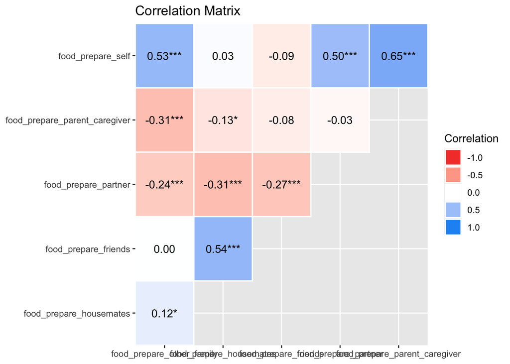

```r
data_cor |>
  summary() |>
  plot()
```

Este bloque convierte las correlaciones en matriz para usarlas en pasos posteriores.

```r
data_cor_mtx <- as.matrix(data_cor)

# Mostrar la matriz de correlaciones
round(data_cor_mtx, 2)
```

```
                              food_prepare_self food_prepare_parent_caregiver
food_prepare_self                          1.00                          0.65
food_prepare_parent_caregiver              0.65                          1.00
food_prepare_partner                       0.50                         -0.03
food_prepare_friends                      -0.09                         -0.08
food_prepare_housemates                    0.03                         -0.13
food_prepare_other_family                  0.53                         -0.31
                              food_prepare_partner food_prepare_friends
food_prepare_self                             0.50                -0.09
food_prepare_parent_caregiver                -0.03                -0.08
food_prepare_partner                          1.00                -0.27
food_prepare_friends                         -0.27                 1.00
food_prepare_housemates                      -0.31                 0.54
food_prepare_other_family                    -0.24                 0.00
                              food_prepare_housemates food_prepare_other_family
food_prepare_self                                0.03                      0.53
food_prepare_parent_caregiver                   -0.13                     -0.31
food_prepare_partner                            -0.31                     -0.24
food_prepare_friends                             0.54                      0.00
food_prepare_housemates                          1.00                      0.12
food_prepare_other_family                        0.12                      1.00
```

## ¿Los datos son apropiados para un EFA? Tests formales

Este bloque calcula el KMO para evaluar la adecuación factorial.

```r
# KMO
psych::KMO(data_cor)
```

[output not shown]

```
Kaiser-Meyer-Olkin factor adequacy
Call: psych::KMO(r = data_cor)
Overall MSA =  0.5
MSA for each item =
            food_prepare_self food_prepare_parent_caregiver
                          0.5                           0.5
         food_prepare_partner          food_prepare_friends
                          0.5                           0.5
      food_prepare_housemates     food_prepare_other_family
                          0.5                           0.5
```

Este bloque aplica el test de Bartlett para revisar la matriz de correlaciones.

```r
# test de Bartlett
cortest.bartlett(R = data_cor,  # usa la matriz de correlación
                 n = 590)       # tamaño de la muestra
```

```
$chisq
[1] 433.4916

$p.value
[1] 6.21172e-83

$df
[1] 15
```

Este bloque evalúa si los datos son apropiados para un análisis factorial.

```r
performance::check_factorstructure(data_prepare)
```

```
# Is the data suitable for Factor Analysis?


  - Sphericity: Bartlett's test of sphericity suggests that there is sufficient significant correlation in the data for factor analysis (Chisq(15) = 221.63, p < .001).
  - KMO: The Kaiser, Meyer, Olkin (KMO) overall measure of sampling adequacy suggests that factor analysis is likely to be inappropriate (KMO = 0.39). The individual KMO scores are: food_prepare_self (0.42*), food_prepare_parent_caregiver (0.38*), food_prepare_partner (0.35*), food_prepare_friends (…
```

## `parallel análisis`: Identificar el número de factores

Este bloque usa análisis paralelo para orientar el número de factores.

```r
psych::fa.parallel(data_prepare,
                   fm = "minres", # Minimal residuals
                   cor = "tet",   # porque los items son dicotómicos
                   fa = "fa")   # para PCA sólo cambiar a "pca" o "both"
```

```
Parallel analysis suggests that the number of factors =  4  and the number of components =  NA
```

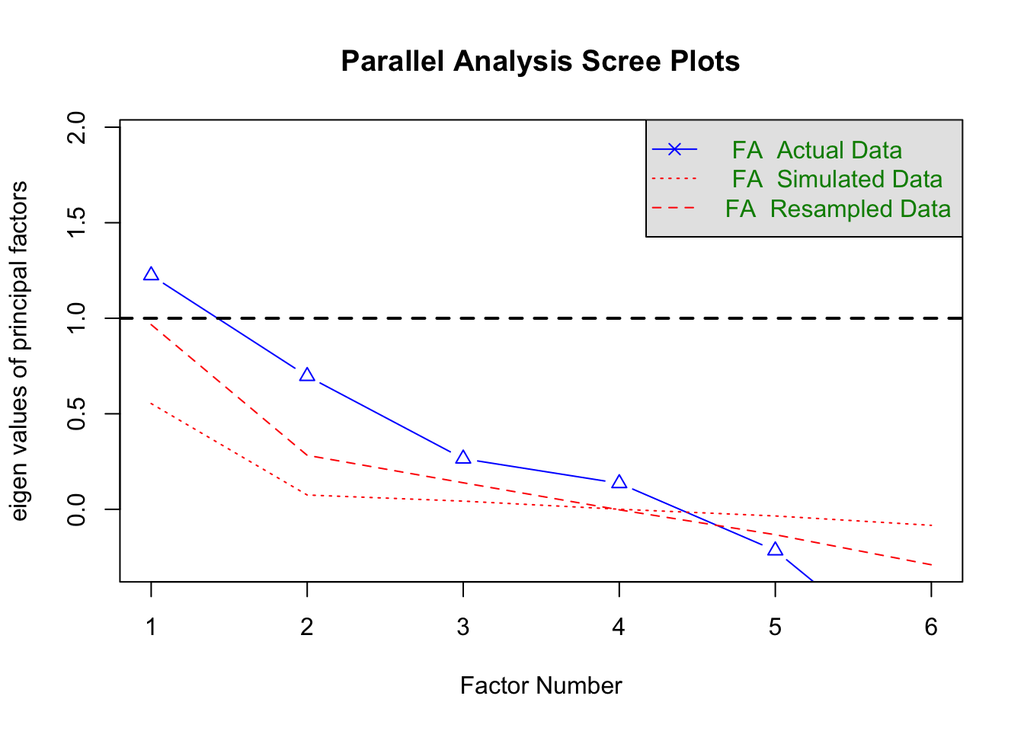

```r
abline(h = 1, col = "black", lty = 2, lwd = 2)
```

## `Eigen values`: Identificar el número de factores

Este bloque extrae eigenvalues para orientar el número de factores.

```r
m0 <- psych::fa(data_prepare,
                nfactors = 6, # igual al número de ítems
                rotate = "none")

# verificar los eigenvalues mayores que 1
m0$values[m0$values > 1]
```

```
[1] 1.091844
```

## `parameters::n_factor` múltiples formas de evaluar el número de factores

Este bloque compara varios criterios para decidir el número de factores.

```r
prepare_n_factors <- parameters::n_factors(x = data_prepare,
                                         type = "FA",
                                         rotation = "varimax",
                                         algorithm = "minres",
                                         cor = data_cor_mtx)

prepare_n_factors
```

| n_Factors | Method | Family |
| --- | --- | --- |
| 0 | Scree (SE) | Scree_SE |
| 0 | Scree (R2) | Scree_SE |
| 1 | Optimal coordinates | Scree |
| 1 | Acceleration factor | Scree |
| 1 | Velicer's MAP | Velicers_MAP |
| 2 | BIC | BIC |
| 2 | BIC (adjusted) | BIC |
| 3 | Bentler | Bentler |
| 3 | CNG | CNG |
| 3 | Parallel analysis | Scree |

[output cut: 6 more lines]

Este bloque presenta los parámetros del modelo en una tabla interpretativa.

```r
parameters::display(prepare_n_factors)
```

| n_Factors | Method | Family |
| --- | --- | --- |
| 0 | Scree (SE) | Scree_SE |
| 0 | Scree (R2) | Scree_SE |
| 1 | Optimal coordinates | Scree |
| 1 | Acceleration factor | Scree |
| 1 | Velicer’s MAP | Velicers_MAP |
| 2 | BIC | BIC |
| 2 | BIC (adjusted) | BIC |
| 3 | Bentler | Bentler |
| 3 | CNG | CNG |
| 3 | Parallel analysis | Scree |
| 3 | Kaiser criterion | Scree |
| 4 | VSS complexity 1 | VSS |
| 5 | Bartlett | Barlett |
| 5 | Anderson | Barlett |
| 5 | Lawley | Barlett |
| 5 | VSS complexity 2 | VSS |

## `parameters::n_factor`: múltiples formas de evaluar el número de factores

Este bloque visualiza el resultado del análisis anterior.

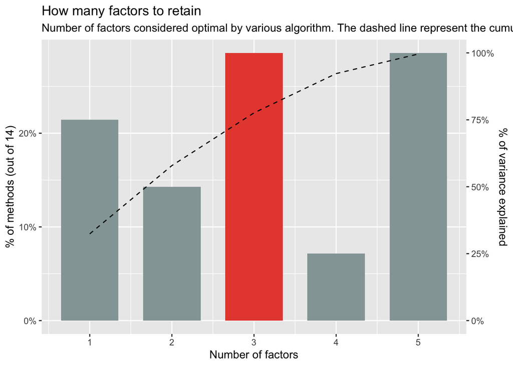

```r
plot(prepare_n_factors)
```

## Estimar el modelo: EFA con dos factores

Este bloque estima el modelo factorial exploratorio.

```r
m1 <- parameters::factor_analysis(
  x = data_prepare,
  n = 2,
  rotation = "oblimin",
  scores = "regression",
  cor = "tet"
)
```

```
In smc, smcs < 0 were set to .0
In smc, smcs < 0 were set to .0
In smc, smcs < 0 were set to .0
```

## Revisar el ajuste del modelo: ajuste global

Este bloque revisa el ajuste global del modelo estimado.

```r
performance::model_performance(m1) |>
  display()
```

| Chi2(4) | p (Chi2) | RMSR | RMSR_corrected | TLI | RMSEA | RMSEA 90% CI | BIC |
| --- | --- | --- | --- | --- | --- | --- | --- |
| 12574.98 | < .001 | 0.13 | 0.25 | -2.55 | 2.31 | [2.28, 2.34] | 12549.5 |

## Revisar el ajuste del modelo: `residuos` y `normalidad`

Este bloque revisa los residuos del modelo factorial.

```r
performance::check_residuals(m1)
```

```
OK: residuals appear as normally distributed (p = 0.332).

Absolute residuals > 0.05 = 8 (53.33%)
```

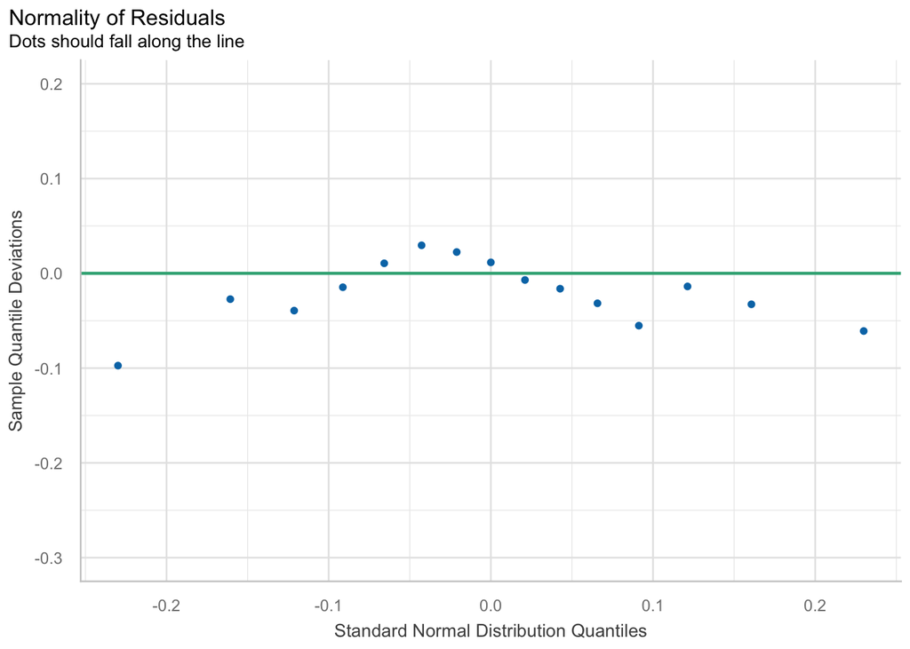

```r
performance::check_normality(m1) |>
  plot()
```

## Inspecionar e interpretar el modelo: `factor loadings`

Este bloque presenta los parámetros del modelo en una tabla interpretativa.

```r
m1 |>
  parameters::display(threshold = 0.2, # eliminar si quieren ver todas las cargas
                      sort = TRUE)
```

Rotated loadings from Factor Analysis (oblimin-rotation)

| Variable | MR1 | MR2 | Complexity | Uniqueness |
| --- | --- | --- | --- | --- |
| food_prepare_self | 1.06 |  | 1.00 | -0.11 |
| food_prepare_parent_caregiver | 0.40 |  | 1.16 | 0.82 |
| food_prepare_other_family | 0.27 | 0.22 | 1.94 | 0.89 |
| food_prepare_housemates |  | 0.83 | 1.01 | 0.31 |
| food_prepare_friends |  | 0.61 | 1.02 | 0.62 |
| food_prepare_partner | 0.28 | -0.38 | 1.82 | 0.76 |

The 2 latent factors (oblimin rotation) accounted for 45.26% of the total variance of the original data (MR1 = 23.90%, MR2 = 21.36%).

## Inspecionar e interpretar el modelo: `Varianza explicada`

Este bloque resume y visualiza el patrón de correlaciones.

```r
m1 |>
  summary()
```

| Parameter | MR1 | MR2 |
| --- | --- | --- |
| Eigenvalues | 1.6121566 | 1.1983168 |
| Variance | 0.2390427 | 0.2135551 |
| Variance_Cumulative | 0.2390427 | 0.4525977 |
| Variance_Proportion | 0.5281570 | 0.4718430 |

## Guardar las puntuaciones de los factores (`factor scores`)

Este bloque extrae las puntuaciones factoriales para cada participante.

```r
m1_scores <- parameters::factor_scores(m1)

head(m1_scores)
```

|  | MR1 | MR2 |
| --- | --- | --- |
| 1 | 2.9391734 | -0.33738934 |
| 2 | -0.3820747 | -0.06171308 |
| 3 | -0.3820747 | -0.06171308 |
| 4 | -0.2979025 | -1.01166105 |
| 5 | -0.3820747 | -0.06171308 |
| 6 | -0.3820747 | -0.06171308 |

# Ejercicio

## Ejercicio: EFA con hábitos de alimentación

Vamos a adaptar la práctica anterior a un subconjunto de datos llamado `data_eat`, que contiene los ítems de frecuencia de consumo de alimentos.

```r
eat_fruit
eat_vegetables
eat_calcium
eat_white_meat
eat_red_meat
eat_processed_meat
eat_seafood
eat_legumes
eat_sweets
eat_fast_food
eat_convenience_food
eat_home_cooked
eat_breakfast
eat_snacks
```

### Instrucciones

1. Crea el subconjunto `data_eat` con las variables de alimentación.
2. Explora inicialmente los datos: estructura, descriptivos, valores perdidos y distribuciones.
3. Calcula e inspecciona la matriz de correlaciones entre los ítems.
4. Evalúa si los datos son apropiados para un EFA usando funciones del paquete `performance`.
5. Identifica el número de factores con análisis paralelo, eigenvalues y `parameters::n_factors()`.
6. Estima un modelo EFA con rotación oblicua.
7. Revisa la salida del modelo e interpreta las cargas factoriales, comunalidades, varianza explicada y ajuste global.

Como los ítems son ordinales, una opción conservadora es usar correlaciones ordinales/policóricas. Para que el ejercicio sea estable en clase, la solución usa correlaciones de Spearman.

## Solución 1. Crear `data_eat`

Este bloque prepara o verifica las variables seleccionadas para el análisis.

```r
data_eat <- data |>
  dplyr::select(
    eat_fruit,
    eat_vegetables,
    eat_calcium,
    eat_white_meat,
    eat_red_meat,
    eat_processed_meat,
    eat_seafood,
    eat_legumes,
    eat_sweets,
    eat_fast_food,
    eat_convenience_food,
    eat_home_cooked,
    eat_breakfast,
    eat_snacks
  )

names(data_eat)
```

```
 [1] "eat_fruit"            "eat_vegetables"       "eat_calcium"
 [4] "eat_white_meat"       "eat_red_meat"         "eat_processed_meat"
 [7] "eat_seafood"          "eat_legumes"          "eat_sweets"
[10] "eat_fast_food"        "eat_convenience_food" "eat_home_cooked"
[13] "eat_breakfast"        "eat_snacks"
```

El subconjunto incluye 14 ítems. Todos representan frecuencias de consumo, aunque algunos apuntan a patrones potencialmente más saludables, como frutas y verduras, y otros a patrones menos saludables, como dulces, comida rápida o alimentos de conveniencia.

## Solución 2. Exploración inicial

Este bloque revisa la estructura general de los datos.

```r
dplyr::glimpse(data_eat)
```

```
Rows: 590
Columns: 14
$ eat_fruit            <dbl> 4, 2, 6, 4, 4, 1, 3, 4, 5, 1, 2, 3, 2, 2, 5, 4, 4…
$ eat_vegetables       <dbl> 3, 2, 5, 3, 4, 1, 4, 5, 3, 1, 4, 3, 2, 2, 5, 4, 4…
$ eat_calcium          <dbl> 4, 3, 6, 2, 6, 3, 6, 7, 4, 3, 4, 6, 7, 6, 7, 7, 7…
$ eat_white_meat       <dbl> 2, 4, 3, 3, 3, 2, 0, 3, 4, 3, 3, 6, 0, 4, 6, 6, 2…
$ eat_red_meat         <dbl> 2, 1, 0, 3, 2, 2, 0, 2, 4, 3, 4, 1, 0, 3, 3, 2, 2…
$ eat_processed_meat   <dbl> 1, 6, 0, 1, 1, 2, 0, 3, 2, 1, 1, 1, 0, 3, 1, 4, 2…
$ eat_seafood          <dbl> 1, 0, 3, 1, 1, 1, 0, 2, 1, 0, 2, 2, 0, 2, 3, 1, 0…
$ eat_legumes          <dbl> 1, 0, 3, 0, 0, 1, 6, 2, 1, 0, 1, 0, 4, 0, 1, 2, 3…
$ eat_sweets           <dbl> 6, 1, 4, 3, 2, 2, 6, 6, 2, 3, 6, 1, 8, 4, 2, 1, 2…
$ eat_fast_food        <dbl> 1, 0, 1, 2, 2, 1, 1, 1, 2, 2, 1, 2, 2, 1, 1, 2, 1…
$ eat_convenience_food <dbl> 1, 1, 2, 1, 1, 0, 2, 3, 3, 2, 2, 0, 2, 2, 1, 1, 1…
$ eat_home_cooked      <dbl> 4, 7, 6, 4, 3, 4, 6, 4, 4, 3, 8, 6, 7, 4, 6, 7, 4…
$ eat_breakfast        <dbl> 3, 3, 3, 2, 0, 2, 0, 2, 2, 2, 0, 2, 2, 2, 2, 3, 2…
$ eat_snacks           <dbl> 5, 3, 4, 3, 2, 3, 2, 6, 2, 3, 6, 1, 6, 4, 0, 4, 3…
```

Este bloque obtiene descriptivos para revisar las variables seleccionadas.

```r
psych::describe(data_eat)
```

|  | vars | n | mean | sd | median | trimmed | mad | min | max | range | skew | kurtosis | se |
| --- | --- | --- | --- | --- | --- | --- | --- | --- | --- | --- | --- | --- | --- |
| eat_fruit | 1 | 569 | 2.822496 | 1.646097 | 3 | 2.842451 | 1.4826 | 0 | 6 | 6 | -0.08678028 | -1.1862823 | 0.06900796 |
| eat_vegetables | 2 | 573 | 2.993019 | 1.626900 | 3 | 3.034858 | 1.4826 | 0 | 6 | 6 | -0.19303558 | -1.0897140 | 0.06796473 |
| eat_calcium | 3 | 590 | 4.574576 | 2.040431 | 6 | 4.641949 | 2.9652 | 0 | 8 | 8 | -0.25216618 | -1.1923919 | 0.08400322 |
| eat_white_meat | 4 | 590 | 3.362712 | 1.931061 | 3 | 3.300847 | 1.4826 | 0 | 8 | 8 | 0.49096513 | -0.2487567 | 0.07950054 |
| eat_red_meat | 5 | 590 | 2.032203 | 1.738600 | 2 | 1.750000 | 1.4826 | 0 | 8 | 8 | 1.39422154 | 1.7305047 | 0.07157703 |
| eat_processed_meat | 6 | 590 | 1.496610 | 1.626131 | 1 | 1.199153 | 1.4826 | 0 | 7 | 7 | 1.45697960 | 1.7557910 | 0.06694674 |
| eat_seafood | 7 | 590 | 1.332203 | 1.491850 | 1 | 1.057203 | 1.4826 | 0 | 8 | 8 | 2.01326595 | 4.6825174 | 0.06141849 |
| eat_legumes | 8 | 590 | 2.054237 | 1.666745 | 2 | 1.828390 | 1.4826 | 0 | 8 | 8 | 1.36817365 | 2.1352023 | 0.06861880 |
| eat_sweets | 9 | 590 | 3.500000 | 1.995538 | 3 | 3.398305 | 1.4826 | 0 | 8 | 8 | 0.49717588 | -0.7926704 | 0.08215501 |
| eat_fast_food | 10 | 590 | 1.481356 | 1.216256 | 1 | 1.326271 | 1.4826 | 0 | 7 | 7 | 2.05553735 | 6.2324410 | 0.05007246 |

[output cut: 4 more lines]

Este bloque revisa cuántos valores perdidos hay en cada ítem.

```r
data_eat |>
  dplyr::summarise(
    dplyr::across(
      .cols = dplyr::everything(),
      .fns = ~ sum(is.na(.x))
    )
  ) |>
  tidyr::pivot_longer(
    cols = dplyr::everything(),
    names_to = "Item",
    values_to = "Missing"
  )
```

| Item | Missing |
| --- | --- |
| eat_fruit | 21 |
| eat_vegetables | 17 |
| eat_calcium | 0 |
| eat_white_meat | 0 |
| eat_red_meat | 0 |
| eat_processed_meat | 0 |
| eat_seafood | 0 |
| eat_legumes | 0 |
| eat_sweets | 0 |
| eat_fast_food | 0 |

[output cut: 4 more lines]

La exploración inicial permite detectar si hay ítems con poca variabilidad, muchos valores perdidos o escalas que no estén en el formato esperado. Para estimar el modelo usaremos una base sin valores perdidos.

## Solución 2. Distribuciones de los ítems

Este bloque visualiza la distribución de las respuestas por ítem.

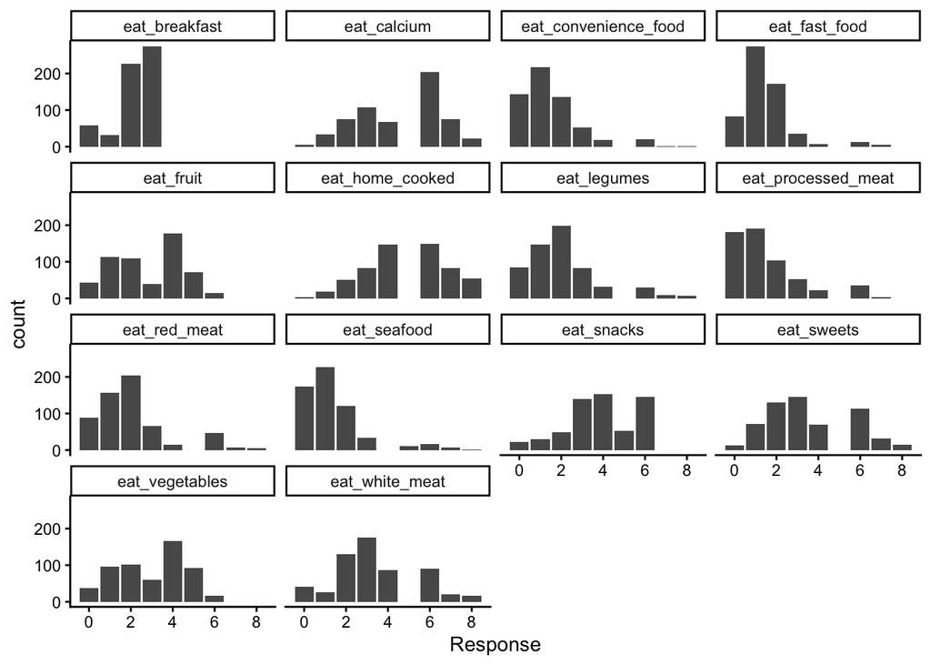

```r
data_eat |>
  tidyr::pivot_longer(
    cols = dplyr::everything(),
    names_to = "Item",
    values_to = "Response"
  ) |>
  ggplot2::ggplot(mapping = aes(x = Response)) +
  ggplot2::geom_bar() +
  ggplot2::facet_wrap(~ Item) +
  ggplot2::theme_classic()
```

Aquí conviene mirar si algún ítem tiene categorías casi vacías o una distribución demasiado concentrada en una sola respuesta. Ese patrón puede reducir la utilidad del ítem para un EFA.

## Solución 3. Correlaciones entre ítems

Este bloque calcula las correlaciones entre las variables seleccionadas.

```r
data_eat_cor <- cor(
  x = data_eat,
  use = "pairwise.complete.obs",
  method = "spearman"
)

round(data_eat_cor, digits = 2)
```

```
                     eat_fruit eat_vegetables eat_calcium eat_white_meat
eat_fruit                 1.00           0.54        0.41           0.09
eat_vegetables            0.54           1.00        0.45           0.10
eat_calcium               0.41           0.45        1.00           0.17
eat_white_meat            0.09           0.10        0.17           1.00
eat_red_meat              0.09           0.06        0.16           0.39
eat_processed_meat        0.07           0.07        0.10           0.29
eat_seafood               0.14           0.05        0.09           0.23
eat_legumes               0.27           0.22        0.22           0.05
eat_sweets                0.04           0.07        0.12           0.08
eat_fast_food            -0.08          -0.07        0.04           0.18
eat_convenience_food     -0.02          -0.02        0.06           0.10
eat_home_cooked           0.13           0.17        0.21           0.18
eat_breakfast             0.26           0.11        0.22           0.04
eat_snacks                0.12           0.04        0.11           0.07
                     eat_red_meat eat_processed_meat eat_seafood eat_legumes
eat_fruit                    0.09               0.07        0.14        0.27
eat_vegetables               0.06               0.07        0.05        0.22
eat_calcium                  0.16               0.10        0.09        0.22
eat_white_meat               0.39               0.29        0.23        0.05
eat_red_meat                 1.00               0.36        0.31        0.09
eat_processed_meat           0.36               1.00        0.16       -0.03
eat_seafood                  0.31               0.16        1.00        0.22
eat_legumes                  0.09              -0.03        0.22        1.00
eat_sweets                   0.11               0.23        0.02        0.01
eat_fast_food                0.29               0.27        0.07        0.03
eat_convenience_food         0.12               0.26        0.04        0.06
eat_home_cooked              0.05              -0.14        0.11        0.21
eat_breakfast                0.00              -0.07        0.09        0.18
eat_snacks                   0.00               0.13        0.03        0.10
                     eat_sweets eat_fast_food eat_convenience_food
eat_fruit                  0.04         -0.08                -0.02
eat_vegetables             0.07         -0.07                -0.02
eat_calcium                0.12          0.04                 0.06
eat_white_meat             0.08          0.18                 0.10
eat_red_meat               0.11          0.29                 0.12
eat_processed_meat         0.23          0.27                 0.26
eat_seafood                0.02          0.07                 0.04
eat_legumes                0.01          0.03                 0.06
eat_sweets                 1.00          0.27                 0.31
eat_fast_food              0.27          1.00                 0.45
eat_convenience_food       0.31          0.45                 1.00
eat_home_cooked           -0.07         -0.17                -0.19
eat_breakfast             -0.03         -0.12                -0.11
eat_snacks                 0.38          0.12                 0.15
                     eat_home_cooked eat_breakfast eat_snacks
eat_fruit                       0.13          0.26       0.12
eat_vegetables                  0.17          0.11       0.04
eat_calcium                     0.21          0.22       0.11
eat_white_meat                  0.18          0.04       0.07
eat_red_meat                    0.05          0.00       0.00
eat_processed_meat             -0.14         -0.07       0.13
eat_seafood                     0.11          0.09       0.03
eat_legumes                     0.21          0.18       0.10
eat_sweets                     -0.07         -0.03       0.38
eat_fast_food                  -0.17         -0.12       0.12
eat_convenience_food           -0.19         -0.11       0.15
eat_home_cooked                 1.00          0.20       0.03
eat_breakfast                   0.20          1.00       0.12
eat_snacks                      0.03          0.12       1.00
```

Este bloque calcula las correlaciones entre las variables seleccionadas.

```r
data_eat |>
  correlation::correlation(method = "spearman") |>
  correlation::display()
```

Correlation Matrix (spearman-method)

| Parameter1 | Parameter2 | rho | 95% CI | S | p |
| --- | --- | --- | --- | --- | --- |
| eat_fruit | eat_vegetables | 0.54 | (0.47, 0.59) | 1.37e+07 | < .001*** |
| eat_fruit | eat_calcium | 0.41 | (0.33, 0.47) | 1.82e+07 | < .001*** |
| eat_fruit | eat_white_meat | 0.09 | (3.81e-03, 0.17) | 2.80e+07 | > .999 |
| eat_fruit | eat_red_meat | 0.09 | (6.92e-04, 0.17) | 2.81e+07 | > .999 |
| eat_fruit | eat_processed_meat | 0.07 | (-0.01, 0.16) | 2.84e+07 | > .999 |
| eat_fruit | eat_seafood | 0.14 | (0.06, 0.22) | 2.63e+07 | 0.035* |
| eat_fruit | eat_legumes | 0.27 | (0.19, 0.35) | 2.23e+07 | < .001*** |
| eat_fruit | eat_sweets | 0.04 | (-0.04, 0.13) | 2.94e+07 | > .999 |
| eat_fruit | eat_fast_food | -0.08 | (-0.16, 8.62e-03) | 3.30e+07 | > .999 |
| eat_fruit | eat_convenience_food | -0.02 | (-0.10, 0.07) | 3.13e+07 | > .999 |
| eat_fruit | eat_home_cooked | 0.13 | (0.05, 0.21) | 2.67e+07 | 0.094 |
| eat_fruit | eat_breakfast | 0.26 | (0.17, 0.33) | 2.29e+07 | < .001*** |
| eat_fruit | eat_snacks | 0.12 | (0.04, 0.20) | 2.70e+07 | 0.175 |
| eat_vegetables | eat_calcium | 0.45 | (0.38, 0.51) | 1.73e+07 | < .001*** |
| eat_vegetables | eat_white_meat | 0.10 | (0.02, 0.19) | 2.81e+07 | 0.557 |
| eat_vegetables | eat_red_meat | 0.06 | (-0.03, 0.14) | 2.95e+07 | > .999 |
| eat_vegetables | eat_processed_meat | 0.07 | (-9.49e-03, 0.16) | 2.90e+07 | > .999 |
| eat_vegetables | eat_seafood | 0.05 | (-0.03, 0.14) | 2.97e+07 | > .999 |
| eat_vegetables | eat_legumes | 0.22 | (0.14, 0.30) | 2.45e+07 | < .001*** |
| eat_vegetables | eat_sweets | 0.07 | (-0.01, 0.16) | 2.91e+07 | > .999 |
| eat_vegetables | eat_fast_food | -0.07 | (-0.15, 0.02) | 3.34e+07 | > .999 |
| eat_vegetables | eat_convenience_food | -0.02 | (-0.10, 0.07) | 3.18e+07 | > .999 |
| eat_vegetables | eat_home_cooked | 0.17 | (0.09, 0.25) | 2.60e+07 | 0.002** |
| eat_vegetables | eat_breakfast | 0.11 | (0.03, 0.20) | 2.78e+07 | 0.291 |
| eat_vegetables | eat_snacks | 0.04 | (-0.05, 0.12) | 3.02e+07 | > .999 |
| eat_calcium | eat_white_meat | 0.17 | (0.09, 0.25) | 2.83e+07 | 0.002** |
| eat_calcium | eat_red_meat | 0.16 | (0.08, 0.24) | 2.86e+07 | 0.004** |
| eat_calcium | eat_processed_meat | 0.10 | (0.02, 0.18) | 3.08e+07 | 0.627 |
| eat_calcium | eat_seafood | 0.09 | (3.57e-03, 0.17) | 3.13e+07 | > .999 |
| eat_calcium | eat_legumes | 0.22 | (0.14, 0.30) | 2.66e+07 | < .001*** |

[output cut: 61 more lines]

p-value adjustment method: Holm (1979) Observations: 561-590

Buscamos grupos de ítems correlacionados entre sí. Correlaciones cercanas a 0 sugieren poca información compartida; correlaciones extremadamente altas, por ejemplo **r > .90**, pueden indicar redundancia.

## Solución 4. ¿Los datos son apropiados para EFA?

Este bloque crea una base completa y cuenta los casos disponibles.

```r
data_eat_complete <- data_eat |>
  tidyr::drop_na()

nrow(data_eat_complete)
```

```
[1] 561
```

Este bloque evalúa si los datos son apropiados para un análisis factorial.

```r
performance::check_factorstructure(data_eat_complete)
```

```
# Is the data suitable for Factor Analysis?


  - Sphericity: Bartlett's test of sphericity suggests that there is sufficient significant correlation in the data for factor analysis (Chisq(91) = 1498.25, p < .001).
  - KMO: The Kaiser, Meyer, Olkin (KMO) overall measure of sampling adequacy suggests that data seems appropriate for factor analysis (KMO = 0.74). The individual KMO scores are: eat_fruit (0.72), eat_vegetables (0.69), eat_calcium (0.81), eat_white_meat (0.75), eat_red_meat (0.76), eat_processed_me…
```

`check_factorstructure()` resume dos diagnósticos importantes: KMO, que evalúa si el patrón de correlaciones es suficientemente compacto, y Bartlett, que evalúa si la matriz de correlaciones difiere de una matriz de identidad.

## Solución 4. Revisar KMO y Bartlett por separado

Este bloque calcula el KMO para evaluar la adecuación factorial.

```r
performance::check_kmo(data_eat_complete)
```

```
# KMO Measure of Sampling Adequacy

The Kaiser, Meyer, Olkin (KMO) overall measure of sampling adequacy suggests that data seems appropriate for factor analysis (KMO = 0.74). The individual KMO scores are: eat_fruit (0.72), eat_vegetables (0.69), eat_calcium (0.81), eat_white_meat (0.75), eat_red_meat (0.76), eat_processed_meat (0.80)…
```

Este bloque aplica el test de Bartlett para revisar la matriz de correlaciones.

```r
performance::check_sphericity_bartlett(data_eat_complete)
```

```
# Test of Sphericity

Bartlett's test of sphericity suggests that there is sufficient significant correlation in the data for factor analysis (Chisq(91) = 1498.25, p < .001).
```

Si KMO es aceptable y Bartlett es significativo, hay evidencia inicial para continuar con el EFA. Si algunos ítems tienen KMO individual bajo, conviene revisarlos al interpretar la solución.

## Solución 5. Análisis paralelo

Este bloque usa análisis paralelo para orientar el número de factores.

```r
psych::fa.parallel(
  x = data_eat_cor,
  n.obs = nrow(data_eat_complete),
  fm = "minres",
  fa = "fa"
)
```

```
Parallel analysis suggests that the number of factors =  4  and the number of components =  NA
```

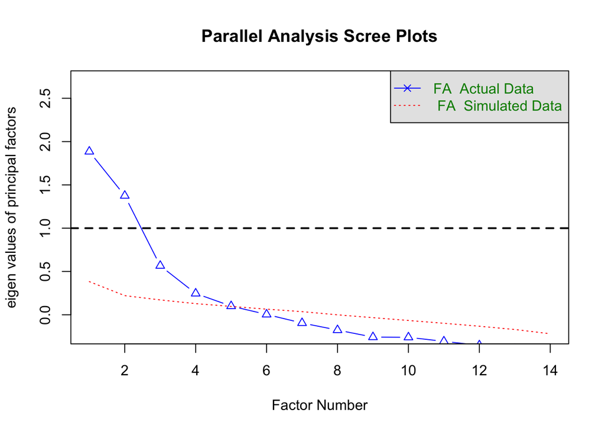

```r
abline(h = 1, col = "black", lty = 2, lwd = 2)
```

El análisis paralelo ayuda a decidir cuántos factores retener comparando los eigenvalues observados con los esperados por azar.

## Solución 5. Eigenvalues

Este bloque calcula eigenvalues para contrastar la decisión sobre factores.

```r
m0_eat <- psych::fa(
  r = data_eat_cor,
  nfactors = ncol(data_eat_cor),
  rotate = "none",
  fm = "minres",
  n.obs = nrow(data_eat_complete)
)

m0_eat$values[m0_eat$values > 1]
```

```
[1] 2.222835 1.780726
```

El criterio de eigenvalues mayores que 1 es una regla orientativa. Conviene contrastarlo con el análisis paralelo y con la interpretabilidad de la solución.

## Solución 5. `parameters::n_factors()`

Este bloque compara varios criterios para decidir el número de factores.

```r
data_eat_n_factors <- parameters::n_factors(
  x = data_eat_complete,
  type = "FA",
  rotation = "oblimin",
  algorithm = "minres",
  cor = data_eat_cor
)

data_eat_n_factors
```

| n_Factors | Method | Family |
| --- | --- | --- |
| 2 | t | Multiple_regression |
| 2 | p | Multiple_regression |
| 2 | Acceleration factor | Scree |
| 2 | Scree (R2) | Scree_SE |
| 2 | Velicer's MAP | Velicers_MAP |
| 3 | Bentler | Bentler |
| 3 | CNG | CNG |
| 3 | Scree (SE) | Scree_SE |
| 4 | beta | Multiple_regression |
| 4 | Optimal coordinates | Scree |

[output cut: 9 more lines]

Este bloque visualiza el resultado del análisis anterior.

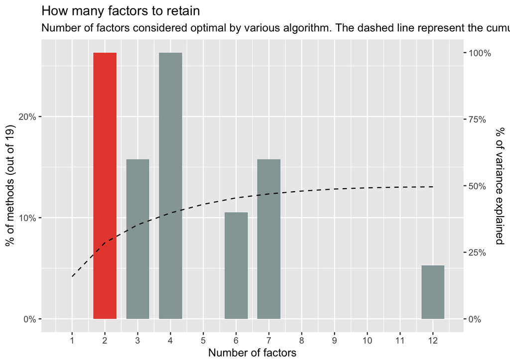

```r
plot(data_eat_n_factors)
```

La decisión final debe integrar los criterios empíricos y la interpretación sustantiva. En esta solución se continúa con una solución de 4 factores como punto de partida.

## Solución 6. Estimar el modelo EFA

Este bloque estima el modelo factorial exploratorio.

```r
m_eat <- parameters::factor_analysis(
  x = data_eat_complete,
  n = 4,
  rotation = "oblimin",
  factor_method = "minres",
  scores = "regression",
  cor = "spearman"
)
```

Usamos `rotation = "oblimin"` porque es razonable esperar que los patrones de alimentación estén relacionados. `factor_method = "minres"` estima el modelo por mínimos residuales y `cor = "spearman"` trata los ítems como ordinales/ordenados.

## Solución 7. Ajuste global del modelo

Este bloque revisa el ajuste global del modelo estimado.

```r
performance::model_performance(m_eat) |>
  display()
```

| Chi2(41) | p (Chi2) | RMSR | RMSR_corrected | TLI | RMSEA | RMSEA 90% CI | BIC |
| --- | --- | --- | --- | --- | --- | --- | --- |
| 106.65 | < .001 | 0.03 | 0.05 | 0.88 | 0.05 | [0.04, 0.07] | -152.9 |

RMSR más bajo indica menos residuos promedio; RMSEA más bajo indica mejor ajuste aproximado; TLI más alto indica mejor ajuste relativo. El $\chi^2$ suele ser significativo con muestras grandes, por lo que no debe interpretarse de forma aislada.

## Solución 7. Cargas factoriales

Este bloque presenta los parámetros del modelo en una tabla interpretativa.

```r
m_eat |>
  parameters::display(
    threshold = 0.25,
    sort = TRUE
  )
```

Rotated loadings from Factor Analysis (oblimin-rotation)

| Variable | MR1 | MR3 | MR2 | MR4 | Complexity | Uniqueness |
| --- | --- | --- | --- | --- | --- | --- |
| eat_vegetables | 0.80 |  |  |  | 1.04 | 0.40 |
| eat_fruit | 0.67 |  |  |  | 1.04 | 0.51 |
| eat_calcium | 0.54 |  |  |  | 1.19 | 0.63 |
| eat_legumes |  |  |  |  | 3.18 | 0.84 |
| eat_red_meat |  | 0.71 |  |  | 1.03 | 0.50 |
| eat_white_meat |  | 0.57 |  |  | 1.04 | 0.68 |
| eat_seafood |  | 0.47 |  |  | 1.34 | 0.77 |
| eat_processed_meat |  | 0.38 | -0.32 |  | 2.08 | 0.68 |
| eat_home_cooked |  |  | 0.49 |  | 1.34 | 0.73 |
| eat_convenience_food |  |  | -0.45 | 0.26 | 1.76 | 0.64 |
| eat_fast_food |  | 0.27 | -0.44 |  | 2.14 | 0.60 |
| eat_breakfast |  |  | 0.39 |  | 1.74 | 0.80 |
| eat_snacks |  |  |  | 0.63 | 1.08 | 0.64 |
| eat_sweets |  |  |  | 0.56 | 1.31 | 0.59 |

The 4 latent factors (oblimin rotation) accounted for 35.78% of the total variance of the original data (MR1 = 11.05%, MR3 = 9.94%, MR2 = 8.02%, MR4 = 6.78%).

Las cargas altas indican qué ítems definen cada factor. Ítems con cargas relevantes en varios factores pueden ser complejos, e ítems con cargas bajas en todos los factores podrían no representar bien la estructura latente.

## Solución 7. Varianza explicada

Este bloque resume y visualiza el patrón de correlaciones.

```r
m_eat |>
  summary()
```

| Parameter | MR1 | MR3 | MR2 | MR4 |
| --- | --- | --- | --- | --- |
| Eigenvalues | 2.0089048 | 1.65246202 | 0.84874042 | 0.4997211 |
| Variance | 0.1104840 | 0.09943087 | 0.08017552 | 0.0677550 |
| Variance_Cumulative | 0.1104840 | 0.20991484 | 0.29009037 | 0.3578454 |
| Variance_Proportion | 0.3087478 | 0.27785989 | 0.22405075 | 0.1893416 |

**SS loadings** resume la varianza explicada por cada factor. **Variance Explained** indica la proporción de varianza explicada y **Variance Explained (Cumulative)** muestra la varianza acumulada por la solución.

## Solución 7. Interpretación sustantiva

Una posible interpretación de la solución de 4 factores es:

- **MR1**: patrón de alimentación saludable, con mayores cargas en fruta, verdura y calcio.
- **MR3**: consumo de proteínas animales, con carnes y pescado.
- **MR2**: contraste entre comida casera y comida rápida/de conveniencia.
- **MR4**: consumo de dulces y snacks.